# WSER-eda

Tomas Castillo

October 8, 2016

## Basic Overview

My project is to explore the data provided from the Western States Endurance Challenge 100 mile run. The reason for choosing this race is because of its status in the ultra running world as the golden standard to compare all other races. It holds the aura of the premiere race to be in, and consistently draws the largest pool of athletes to its waiting list.

The numbers are capped for the race, with a handful of athletes getting based on achievements, others get lucky by getting their name pulled from a lottery. Either way, if you toe the line for the start of the Western States, you will be racing a historic race.

After each race, the race organization not only provides the official finish times, but also the results for time into each aid station. Quick clarifier, an aid station is a position along the race that offers aid (food, drink, area to rest, etc.). Based on the distance an aid station is from the start, this gives us a better overview of how each racer does during the race. We will use this data to see not only how the race has evolved over time, but also to be able to predict how runners will finish, especially as they progress along the course.

## Origin of the Data

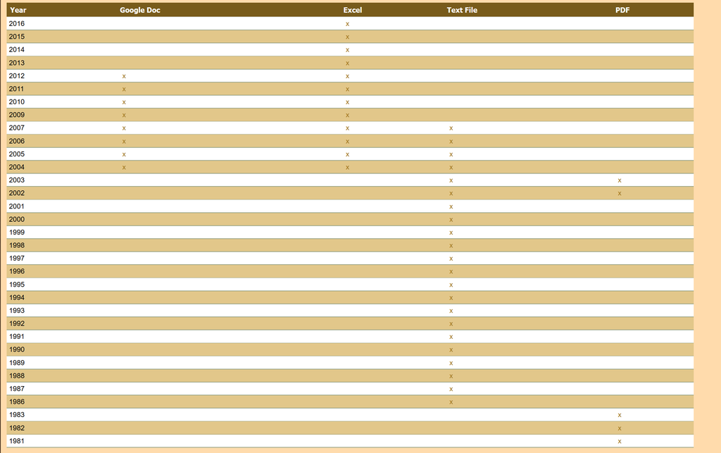

Western States Splits Data

The data that is compiled here had to come in from the different files that are lisited above. When pulling in the data, I had to make a few edits, and therefore I did omit some data from the splits on years where I could not find the distance to a certain aid station. Otherwise, I did try and be as true to the original data as possible by including all information from the aid station for both time in and out of the aid stations.

I came up with a naming convention for each station that is broken down listed below. I’ll list a few of the different ones as it will be helpful for not only you (reader) but for me as well. I’ll include documentation for all the different aid stations for the final project.

| AS Name | Dataset Name | Distance (miles) | In or Out | Type of Measurement |
| --- | --- | --- | --- | --- |
| Red Star Ridge | `t16_in` | 16 | In | Time |
| Red Star Ridge | `p16_in` | 16 | In | Place |
| Duncan Canyon | `t23.8_in` | 23.8 | In | Time |
| Duncan Canyone | `p23.8_in` | 23.8 | In | Place |
| Miller’s Defeat | `t34.4_in` | 34.4 | In | Time |
| Miller’s Defeat | `p34.4_in` | 34.4 | In | Place |
| Miller’s Defeat | `t34.4_out` | 34.4 | Out | Time |
| Miller’s Defeat | `p34.4_out` | 34.4 | Out | Place |

The list goes on, and I got the full list of [aid stations here](http://www.wser.org/course/aid-stations/).

The dataset name listed above was of my own creation, and I used that in order to easily compare year to year and ensure that whatever data was captured from the race would line up with what I had compiled previously. This was a painstakingly long task, but it seems to have paid off (or at least, I hope).

The rationale for the naming convention was an easy way to parse out the different identifiers of the aidstation names and be able to create different columns based on that when converting the data to a long format, once I got to the manipulation of the dataframe.

### Massaging the Data

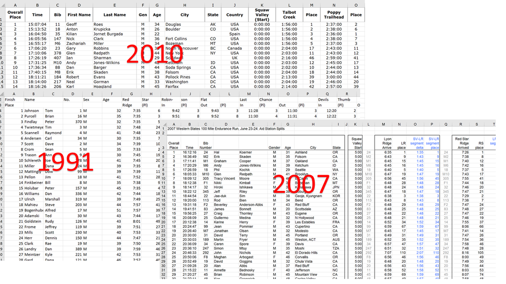

Sample of some raw data

After compiling the different years, I was able to use MS excel and paste together all the runners, and their information for each aid station and finish times for all the years. From there, I then edited a few columns that seemed to have a different formatting than the others, and was able to create a CSV file that I could then pull in with R.

The data still needs quite a bit of wrangling - to make it easy, you can see a short list of tasks that need to be accomplished.

- Convert wide data into long format
- Parse out the aid station information into both a time and place column, along with its value
- Convert all years’ time value for aid stations into time elapsed (except for 2010, 2012-2016)
- Add column for DNF (*Did Not Finish*) - If racer does not have a final time
- Remove NA rows for aid stations

From here, the data will be in a format much more conducive to analyzing and doing what we want. Additional information that would be nice, but seemingly hard to come by, is the elevation change between each aid station. The reason for this challenge is that the course would change from year to year and therefore it is not always the same. The website has some maps available though, so I may be able to plot up the course and extract that data – may be an idea for a future project with this.

### Code for Wrangling

With the outlined goals of our wrangling above, I’ve got a few of the steps (at the time of writing this) completed. Well actually only the first two. The other columns seem to be giving me a bit more trouble than I would’ve liked.

Steps:

1. Gather all the aid station columns using `tidyr::gather` to make a really long and skinny dataset
2. We’ll use some *REGEX* magic to split the aid station name into 3 columns using `tidyr::extract` (that expression took me a long time to come up with!)
   - `t16_in` –> [`t`, `16`, `in`]
3. Create separate columns based on whether the first letter was a `t` or `p` with `tidyr::spread`
4. Reformat a few columns
5. Remove empty aid station times since it doesn’t tell us anything

```r
## Specify columns for aidstations
keycol <- 'AS_time_name'
valuecol <- 'AS_time'

## Use the underscore (_) to easily select headers
gathercols <- colnames(wser)[grep('_', colnames(wser))]

### A regex expression is used to group the titles in the way we want

wserLong <- wser %>%
  gather_(keycol, valuecol, gathercols) %>%
  extract_(keycol, c("AS_indicator", "AS_distance", "AS_InOut"),
           "(^.)([0-9.]*)\\_([:alpha:]*)") %>%
  spread(AS_indicator, AS_time)

# Rename Column Names for p --> AS_Place, t --> AS_Time
colnames(wserLong)[which(names(wserLong) == "p")] <- "AS_Place"
colnames(wserLong)[which(names(wserLong) == "t")] <- "AS_Time"

# Reformat a few of the columns, remove empty aid station values
wserLong$AS_distance <- as.double(wserLong$AS_distance)
wserLong$AS_Place <- as.integer(wserLong$AS_Place)
wserLong$Year <- as.factor(wserLong$Year)
wserLong$Place <- as.integer(wserLong$Place)
wserLong$First.Name <- str_trim(wserLong$First.Name)
wserLong <- wserLong %>% filter(!is.na(AS_Time)) %>% arrange(Year, Place, Last.Name)
```

Now the top of our data looks like this:

```r
## Random Sample of 12 rows of data
wserLong[sample(nrow(wserLong), 12),]
```

```
##        Year Place Last.Name First.Name Bib Sex Age           City State
## 123797 2012     4    Mackey       Dave  M8   M  42         Novato    CA
## 9015   1988    42   Mauldin      Bruce 223   M  40           <NA>  <NA>
## 131212 2013    75    Wright      Chris 411   M  41 Grand Junction    CO
## 135783 2013   374   Schuman      Steve 103   M  50  Beverly Hills    CA
## 62734  1999   227  Anderson     Janice  10   F  33           <NA>  <NA>
## 129126 2012   305       Rao       Anil 326   M  36       San Jose    CA
## 18973  1990   117   Jeffers       Paul 168   M  51           <NA>  <NA>
## 85465  2005     5     Kerby      James  27   M  42           <NA>  <NA>
## 40574  1994   291  Caldwell      Randy 377   M  40           <NA>  <NA>
## 12663  1989    14   Leupold      Bernd  23   M  47           <NA>  <NA>
## 116532 2010   280 Mccartney    Patrick 315   M  38    Knightstown    IN
## 1770   1986   137   Hellman     Warren 215   M  51           <NA>  <NA>
##        timeFinish timeElapsed AS_distance AS_InOut AS_Place  AS_Time
## 123797   20:53:36    15:53:36        98.9       in        4 15:39:00
## 9015      2:38:02    21:38:02        78.0       in       51    20:53
## 131212    4:29:17    23:29:17        93.5       in       82 21:54:00
## 135783       <NA>        <NA>        10.0       in      207  2:24:00
## 62734        <NA>        <NA>        29.7       in       52    11:17
## 129126   10:39:29    29:39:29        62.0       in      247 15:53:00
## 18973     8:05:48    27:05:48        85.2       in      129     3:44
## 85465       23:01    18:01:34        16.0       in        6     8:00
## 40574        <NA>        <NA>        55.7       in      287    19:43
## 12663     0:21:15    19:21:15        85.2       in       15    21:02
## 116532      10:16    29:16:02        62.0       in      323 16:57:00
## 1770      8:15:15    27:15:15        55.7       in      179    17:57
```